# Beta diversity

Yanxian Li Department of Paraclinical Sciences Faculty of Veterinary Medicine Norwegian University of Life Sciences

2021-11-16

# 1 Getting ready

Load packages

```r
library(here) # A Simpler Way to Find Your Files, CRAN
library(tidyverse) # Easily Install and Load the 'Tidyverse', CRAN
library(patchwork) # The Composer of Plots, CRAN
library(ggsignif) # Significance Brackets for 'ggplot2', CRAN
library(RColorBrewer) # ColorBrewer Palettes, CRAN
library(usedist) # Distance Matrix Utilities, CRAN
library(vegan) # Community Ecology Package, CRAN
library(gt) # Easily Create Presentation-Ready Display Tables, CRAN

# Set seed
set.seed(0408)
```

Load data

```r
# metadata
mtd <- read_tsv(here("data/metadata.tsv"), comment = "#q2") %>%
  rename(SampleID = "#SampleID") %>%
  column_to_rownames("SampleID")

# ordination
ord_dgs <- readRDS(here("data/intermediate/qiime2R/beta_diversity_ordination_digesta.rds"))
ord_dgs <- ord_dgs$aitchison$data
ord_mcsFdWt <- readRDS(here("data/intermediate/qiime2R/beta_diversity_ordination_mucosa_feed_water.rds"))
ord_mcsFdWt <- ord_mcsFdWt$aitchison$data

# distance matrix
dist_dgs <- readRDS(here("data/intermediate/qiime2R/beta_diversity_distance_digesta.rds"))
dist_dgs <- dist_dgs$aitchison$data
dist_mcsFdWt <- readRDS(here("data/intermediate/qiime2R/beta_diversity_distance_mucosa_feed_water.rds"))
dist_mcsFdWt <- dist_mcsFdWt$aitchison$data
```

# 2 Ordination

Robust Aitchison PCA (RPCA) is a compositional beta diversity metric rooted in a centered log-ratio (CLR) transformation and matrix completion [(Martino et al., 2019)](https://msystems.asm.org/content/4/1/e00016-19). Aitchison distance was used as the distance metric in the robust Aitchison PCA for its desirable properties: 1)scale invariant, which ensures equivalence between distances computed from absolute and relative abundance measurements, negating the need to perform rarefaction; 2)relative changes driven. Microbes that display large fold change across samples will be weighted more heavily, which makes the ordination robust to random fluctuations of high-abundant taxa; 3)sub-compositionally coherent, which guarantees that distances will never decrease if additional taxa are observed. However, Aitchison distance cannot handle zeros and is thus challenging to apply to the sparse microbiome data. To circumvent this issue, RPCA treats all zeros as missing values and builds a model to handle this missing data using matrix completion.

Note that RPCA is not exactly performing PCA. It is performing PCoA using the Aitchison distance, which is calculated from the Euclidean distance of the CLR-transformed data. Since PCoA with Euclidean distance is equivalent to PCA, the method is called PCA though it’s in fact running PCoA.

## 2.1 Digesta

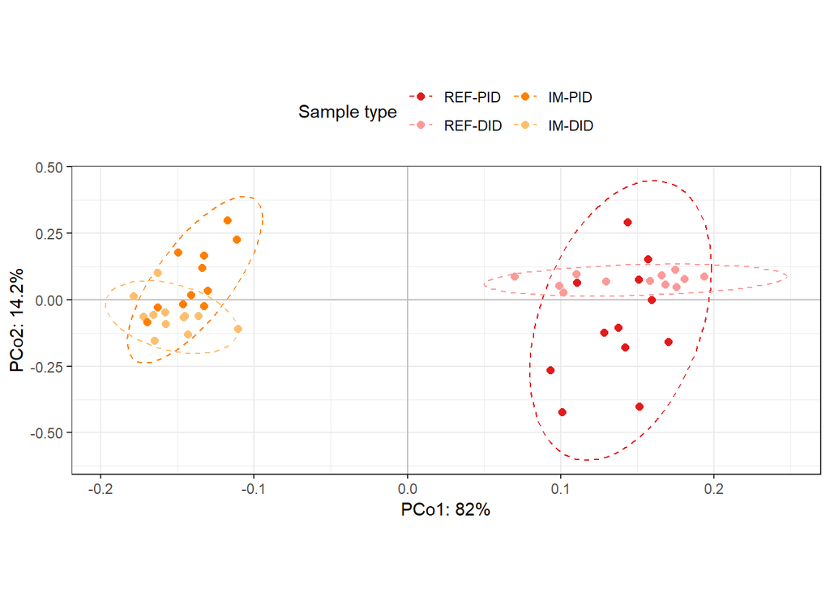

```r
# combine metadata and rpca results
rpca_dgs <- ord_dgs$Vectors %>%
  inner_join(rownames_to_column(mtd, "SampleID"), by = "SampleID") %>%
  filter(!(IsTechnicalReplicate == "yes" & PCRBatch == 2)) %>% # remove technical replicates
  mutate(
    SampleType = factor(
      SampleType,
      levels = c("REF-PID", "REF-DID", "IM-PID", "IM-DID")))

# plot
rpcaPlot_dgs <- ggplot(rpca_dgs, aes(x = PC1, y = PC2, color = SampleType)) +
  geom_hline(yintercept = 0, color = "grey") +
  geom_vline(xintercept = 0, color = "grey") +
  # data ellipse
  stat_ellipse(linetype = "dashed") +
  geom_point(size = 2) +
  # keep the aspect ratio between y and x axis (y-axis/x-axis)
  coord_fixed(ord_dgs$ProportionExplained[2]/ord_dgs$ProportionExplained[1]) +
  labs(
    color = "Sample type",
    x = paste0("PCo1: ", round(100 * ord_dgs$ProportionExplained[1], 1), "%"),
    y = paste0("PCo2: ", round(100 * ord_dgs$ProportionExplained[2], 1), "%")
    ) +
  scale_color_manual(values = brewer.pal(12, "Paired")[c(6, 5, 8, 7)]) +
  guides(color = guide_legend(nrow = 2)) +
  theme_bw(base_size = 11)+
  theme(legend.position = "top")

rpcaPlot_dgs
```

## 2.2 Mucosa, feed and water

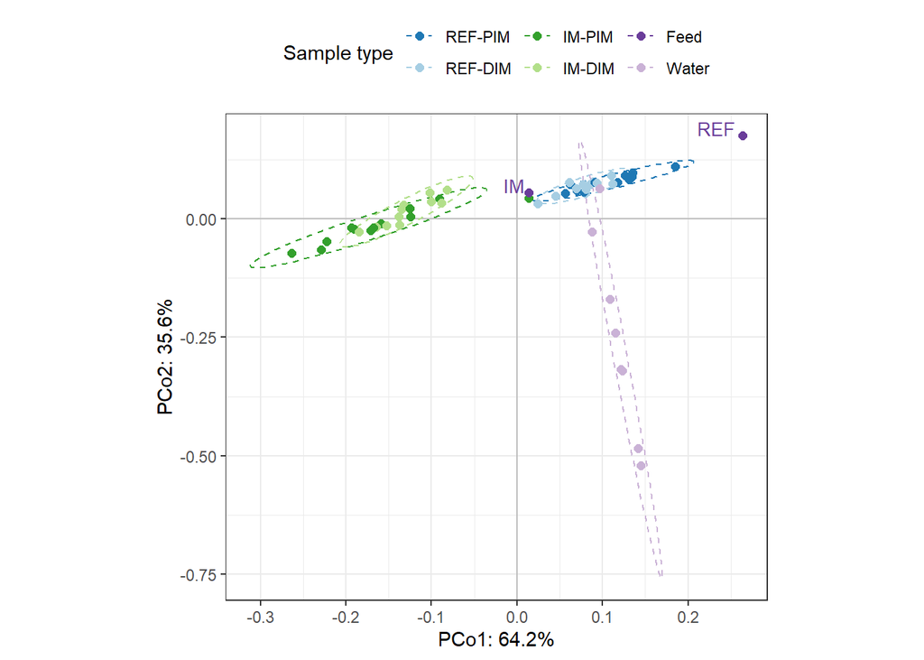

```r
# combine metadata and rpca results
rpca_mcsFdWt <- ord_mcsFdWt$Vectors %>%
  inner_join(rownames_to_column(mtd, "SampleID"), by = "SampleID") %>%
  mutate(
    Diet = factor(Diet, levels = c("REF", "IM")),
    SampleType = factor(
      SampleType,
      levels = c("REF-PIM", "REF-DIM", "IM-PIM", "IM-DIM", "Feed", "Water")
      ),
    Tank = factor(
      Tank,
      levels = c("T02", "T06", "T12", "T18",   # REF diet
                 "T01", "T19", "T21", "T24")   # IM diet
      )
    )

# plot
rpcaPlot_mcsFdWt <- ggplot(rpca_mcsFdWt, aes(x = PC1, y = PC2, color = SampleType)) +
  geom_hline(yintercept = 0, color = "grey") +
  geom_vline(xintercept = 0, color = "grey") +
  stat_ellipse(linetype = "dashed") +
  geom_point(size = 2) +
  geom_text(
    data = filter(rpca_mcsFdWt, SampleType == "Feed"),
    aes(label = Diet), size = 3.5, hjust = 1.2, vjust = 0, show.legend = FALSE
    ) +
  coord_fixed(ord_mcsFdWt$ProportionExplained[2]/ord_mcsFdWt$ProportionExplained[1]) +
  labs(
    color = "Sample type",
    x = paste0("PCo1: ", round(100 * ord_mcsFdWt$ProportionExplained[1], 1), "%"),
    y = paste0("PCo2: ", round(100 * ord_mcsFdWt$ProportionExplained[2], 1), "%")
    ) +
  scale_color_manual(values = brewer.pal(12, "Paired")[c(2, 1, 4, 3, 10, 9)]) +
  theme_bw(base_size = 11)+
  theme(legend.position = "top")

rpcaPlot_mcsFdWt
```

## 2.3 Figure 4

Assemble plots.

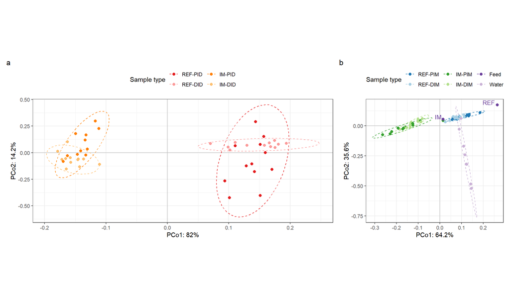

```r
rpcaPlot_dgs + rpcaPlot_mcsFdWt +
  plot_annotation(tag_levels = "a")
```

```r
# export plot
ggsave(here("result/figure/Figure 4.tiff"), width = 12, height = 7,
       units = "in", dpi = 300, compression = "lzw")
```

# 3 PERMANVOA

## 3.1 Export distance matrix

To compare the `Diet` and `Segment` effect, we need to run two-way PERMANOVA with 2 nested random effects (`FishID` and `Tank`). Unfortunately, this can’t be done in R. We export the distance matrix and run the PERMANOVA in [PRIMER v7](https://www.primer-e.com/our-software/permanova-add-on/) using the PERMANOVA add-on.

```r
# digesta samples
dist_subset(dist_dgs, rpca_dgs$SampleID) %>% # subset distance matrix
  as.matrix() %>%
  as.data.frame() %>%
  write.table(
    here("data/intermediate/permanova/Aitchison_distance_digesta.tsv"),
    sep = "\t", col.names = NA, row.names = TRUE
    )

# mucosa and water samples
filter(rpca_mcsFdWt, Source %in% c("Mucosa", "Water")) %>% # get sample ids of mucosa and water samples
  pull(SampleID) %>%
  dist_subset(dist_mcsFdWt, .) %>% # subset distance matrix
  as.matrix() %>%
  as.data.frame() %>%
  write.table(
    here("data/intermediate/permanova/Aitchison_distance_mucosa_water.tsv"),
    sep = "\t", col.names = NA, row.names = TRUE
    )
```

## 3.2 Import PERMANOVA results

```r
pmanova_main <- read_csv(here("data/intermediate/permanova/permanova_main_effects.csv"))
pmanova_cc <- read_csv(here("data/intermediate/permanova/permanova_conditional_contrasts.csv"))
```

## 3.3 Table 2

Merge and format tables.

```r
pmanova <- full_join(pmanova_main, pmanova_cc, by = "Source") %>%
  mutate_all(~gsub("\\*", "", .x)) %>% # remove asterisks denotting Monte Carlo p values
  gt() %>%
  tab_header(title = "PERMANOVA") %>%
  tab_spanner(label = "Main effects", columns = 2:3) %>%
  tab_spanner(label = "Conditional contrasts", columns = 5:8) %>%
  tab_footnote(
    footnote = md("NA: not applicable"),
    locations = cells_body(columns = c(7, 8), rows = 1)
    ) %>%
  tab_footnote(
    footnote = md("NA: not applicable"),
    locations = cells_body(columns = c(5, 6, 7, 8), rows = 2)
    ) %>%
  tab_footnote(
    footnote = md("Monte Carlo *p* value"),
    locations = cells_body(columns = 2, rows = 2)
    ) %>%
  cols_align(align = "center", everything()) %>%
  tab_style(
    style = cell_text(v_align = "middle"),
    locations = cells_column_labels(columns = everything())
  )

pmanova
```

PERMANOVA

| Source | Main effects Diet | Main effects Segment | Interaction | Conditional contrasts REF-PI VS. IM-PI | Conditional contrasts REF-DI VS. IM-DI | Conditional contrasts REF-PI VS. REF-DI | Conditional contrasts IM-PI VS. IM-DI |
| --- | --- | --- | --- | --- | --- | --- | --- |
| Digesta | F = 50.5, p = 0.001 | F = 0.481, p = 0.503 | F = 16.1, p = 0.002 | t = 4.30, p = 0.001 | t = 10.7, p = 0.001 | NA<sup>1</sup> | NA<sup>1</sup> |
| Mucosa | p = 0.001<sup>2</sup> | F = 0.449, p = 0.591 | F = 6.04, p = 0.059 | NA<sup>1</sup> | NA<sup>1</sup> | NA<sup>1</sup> | NA<sup>1</sup> |

<sup>*1*</sup> NA: not applicable <sup>*2*</sup> Monte Carlo *p* value

# 4 PERMDISP

PERMANOVA tests differences in both location and dispersion effects. Although PERMANOVA is robust to heterogeneity in the multivariate dispersion, it’s a good practice to look at the homogeneity of multivariate dispersion following a significant PERMANVOA result. The homogeneity of multivariate dispersion can be assessed visually (PCoA plot/boxplot) or via a permutation test called PERMDISP, which is implemented in R by the `betadisper()` function from the *vegan* package.

## 4.1 Digesta

The PERMANOVA results suggested little evidence of the `Segment` effect. We’ll only need to check the homogeneity of multivariate dispersion for the `Diet` effect. Also, the random effect, `Tank`, was not included in the final PERMANOVA model. Thus, we can use individual fish as the statistical unit when running the PERMDISP. As there’s a significant interaction between the `Diet` and `Segment` effect, we’ll assess the homogeneity of multivariate dispersion for the `Diet` effect within each level of the `Segment`.

Compute beta-dispersion.

```r
disp_dgs <- betadisper(dist_dgs, rpca_dgs$SampleType, type = "median")
disp_dgs
```

[output not shown]

Formal permutation test with `permutest`.

```r
permdisp_dgs <- permutest(disp_dgs, pairwise = TRUE, permutations = 999)
permdisp_dgs
```

```
##
## Permutation test for homogeneity of multivariate dispersions
## Permutation: free
## Number of permutations: 999
##
## Response: Distances
##           Df  Sum Sq Mean Sq      F N.Perm Pr(>F)
## Groups     3  5.0278  1.6759 5.7591    999  0.004 **
## Residuals 43 12.5132  0.2910
## ---
## Signif. codes:  0 '***' 0.001 '**' 0.01 '*' 0.05 '.' 0.1 ' ' 1
##
## Pairwise comparisons:
## (Observed p-value below diagonal, permuted p-value above diagonal)
##           REF-PID   REF-DID    IM-PID IM-DID
## REF-PID           0.0090000 0.1110000  0.004
## REF-DID 0.0097154           0.1960000  0.317
## IM-PID  0.1108462 0.1981066            0.060
## IM-DID  0.0037546 0.2966056 0.0651346
```

Visual inspection.

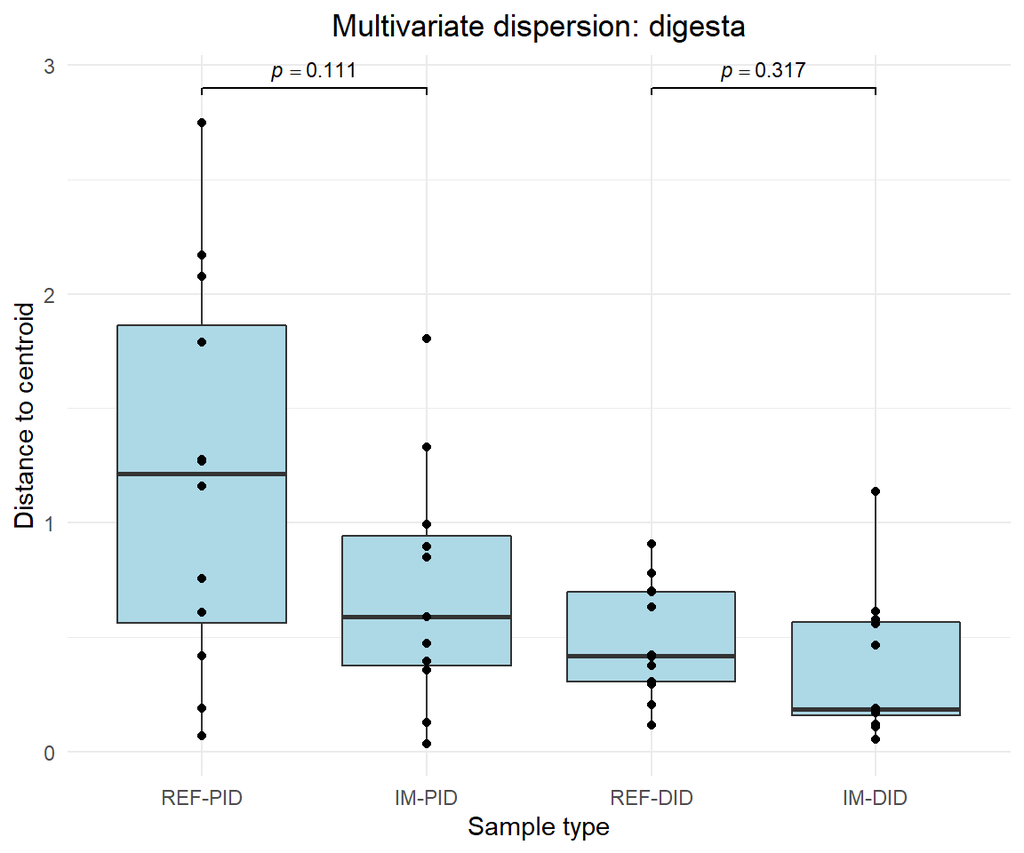

```r
# make a dataframe for annotate p-values
permdisp_dgs_pval <- data.frame(
  pairs = names(permdisp_dgs$pairwise$permuted),
  pval  = permdisp_dgs$pairwise$permuted, row.names = NULL
  ) %>%
  separate(pairs, sep = "-", c("start1", "start2", "end1", "end2")) %>%
  mutate(start = paste0(start1, "-", start2), end = paste0(end1, "-", end2)) %>%
  select(start, end, pval) %>%
  filter(
    (start == "REF-PID" & end == "IM-PID") |
    (start == "REF-DID" & end == "IM-DID")
    ) %>%
  mutate(pval = paste0("italic(p) == ", pval), y = c(2.9, 2.9))

# make plot
dispVis_dgs <- data.frame(dist = disp_dgs$distances, group = disp_dgs$group) %>%
  mutate(group = factor(group, levels = levels(rpca_dgs$SampleType)[c(1, 3, 2, 4)])) %>%
  ggplot(aes(x = group,y = dist)) +
    geom_boxplot(fill = "lightblue") +
    geom_point() +
    # add PERMDISP p values
    geom_signif(
      data = permdisp_dgs_pval,
      aes(xmin = start, xmax = end, annotations = pval, y_position = y),
      tip_length = 0.01,
      textsize = 3,
      parse = TRUE,
      manual = TRUE
      ) +
    labs(
      x = "Sample type", y = "Distance to centroid",
      title = "Multivariate dispersion: digesta"
      ) +
    theme_minimal() +
    theme(plot.title = element_text(hjust = 0.5))

dispVis_dgs
```

## 4.2 Mucosa

The PERMANOVA results suggested little evidence of the `Segment` effect. We’ll only need to check the homogeneity of multivariate dispersion for the `Diet` effect. The random effect, `Tank`, was included in the final PERMANOVA model. Thus, we’ll need to assess the homogeneity of multivariate dispersion for the `Diet` effect at the `Tank` and `Diet` level.

### 4.2.1 Filter data

```r
# filter data to keep mucosa samples only
rpca_mcs <- filter(rpca_mcsFdWt, Source == "Mucosa")

# subset distance matrix
dist_mcs <- dist_subset(dist_mcsFdWt, rpca_mcs$SampleID)
```

### 4.2.2 Tank as centroids

First, we test the homogeneity of multivariate dispersion for `FishID` (replicates) across different `Tank` (centroids).

Compute beta-dispersion.

```r
disp_mcs_tank <- betadisper(dist_mcs, rpca_mcs$Tank, type = "median")
disp_mcs_tank
```

```
##
##  Homogeneity of multivariate dispersions
##
## Call: betadisper(d = dist_mcs, group = rpca_mcs$Tank, type = "median")
##
## No. of Positive Eigenvalues: 3
## No. of Negative Eigenvalues: 0
##
## Average distance to median:
##    T02    T06    T12    T18    T01    T19    T21    T24
## 0.2240 0.3018 0.4876 0.4056 0.2208 0.3335 0.4740 0.4855
##
## Eigenvalues for PCoA axes:
##   PCoA1   PCoA2   PCoA3
## 34.1648  5.6392  0.3468
```

Formal permutation test with `permutest`.

```r
permdisp_mcs_tank <- permutest(disp_mcs_tank, pairwise = TRUE, permutations = 999)
permdisp_mcs_tank
```

```
##
## Permutation test for homogeneity of multivariate dispersions
## Permutation: free
## Number of permutations: 999
##
## Response: Distances
##           Df Sum Sq  Mean Sq      F N.Perm Pr(>F)
## Groups     7 0.5324 0.076053 0.6565    999  0.706
## Residuals 40 4.6338 0.115845
##
## Pairwise comparisons:
## (Observed p-value below diagonal, permuted p-value above diagonal)
##         T02     T06     T12     T18     T01     T19     T21   T24
## T02         0.52600 0.30800 0.20700 0.97200 0.56300 0.25900 0.183
## T06 0.51975         0.44900 0.42200 0.44800 0.85200 0.41700 0.316
## T12 0.28737 0.43125         0.72900 0.27600 0.59600 0.96500 0.996
## T18 0.19786 0.39491 0.73393         0.14900 0.66800 0.75400 0.680
## T01 0.97794 0.41858 0.26318 0.13552         0.50500 0.22300 0.127
## T19 0.54679 0.85120 0.56923 0.69024 0.50402         0.58000 0.481
## T21 0.25876 0.40881 0.96282 0.75007 0.22987 0.56972         0.963
## T24 0.18093 0.30886 0.99388 0.66976 0.14911 0.49738 0.96316
```

Visual inspection.

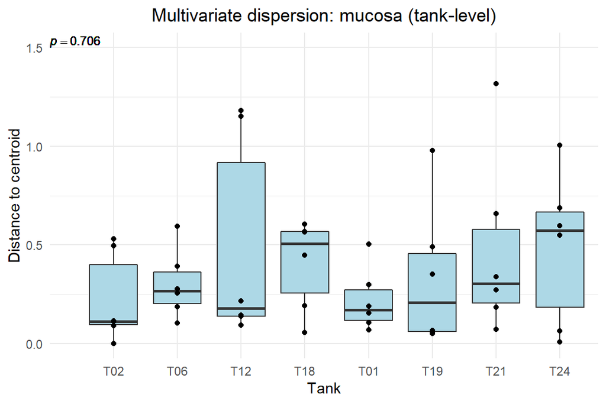

```r
dispVis_mcs_tank <- data.frame(
  dist = disp_mcs_tank$distances,
  group = disp_mcs_tank$group
  ) %>%
  ggplot(aes(x = group,y = dist)) +
    geom_boxplot(fill = "lightblue") +
    geom_point() +
    geom_text(
      aes(
        x = 0,
        y = 1.5,
        label = paste0(
          "italic(p) == ",
          deparse(
            formatC(permdisp_mcs_tank$tab["Groups", "Pr(>F)"], format = "f", digits = 3)
            )
          )
        ),
      size = 3,
      hjust = 0,
      vjust = 0,
      parse = TRUE) +
    labs(
      x = "Tank", y = "Distance to centroid",
      title = "Multivariate dispersion: mucosa (tank-level)"
      ) +
    theme_minimal() +
    theme(plot.title = element_text(hjust = 0.5))

dispVis_mcs_tank
```

### 4.2.3 Diet as centroids

Next, we consider differences in the dispersion of `Tank` centroids around the `Diet` centroids.

Compute distance among the `Tank` centroids.

```r
dist_mcs_tank <- dist_multi_centroids(dist_mcs, rpca_mcs$Tank)
dist_mcs_tank
```

```
##            T02        T06        T12        T18        T01        T19        T21
## T06 0.28401327
## T12 0.30700596 0.06868138
## T18 0.43288893 0.16778862 0.20286880
## T01 1.36170991 1.51766360 1.47573310 1.67667828
## T19 1.15571436 1.29323923 1.24919164 1.44775082 0.26102503
## T21 1.46626892 1.64976215 1.61389202 1.81305126 0.21647571 0.44438889
## T24 1.55299017 1.73584185 1.69963452 1.89868243 0.27444901 0.51152988 0.08889097
```

Make a new mapping metadata for the distance among `Tank` centroids.

```r
mtd_tank <- rpca_mcs %>%
  select(Diet, Tank) %>%
  distinct() %>%
  arrange(Tank)

mtd_tank
```

```
##   Diet Tank
## 1  REF  T02
## 2  REF  T06
## 3  REF  T12
## 4  REF  T18
## 5   IM  T01
## 6   IM  T19
## 7   IM  T21
## 8   IM  T24
```

Compute beta-dispersion.

```r
disp_mcs_diet <- betadisper(dist_mcs_tank, mtd_tank$Diet, type = "median")
disp_mcs_diet
```

```
##
##  Homogeneity of multivariate dispersions
##
## Call: betadisper(d = dist_mcs_tank, group = mtd_tank$Diet, type = "median")
##
## No. of Positive Eigenvalues: 3
## No. of Negative Eigenvalues: 0
##
## Average distance to median:
##    REF     IM
## 0.1301 0.1835
##
## Eigenvalues for PCoA axes:
##    PCoA1    PCoA2    PCoA3
## 4.848278 0.094226 0.005877
```

Formal permutation test with `permutest`.

```r
permdisp_mcs_diet <- permutest(disp_mcs_diet, pairwise = TRUE, permutations = 999)
permdisp_mcs_diet
```

```
##
## Permutation test for homogeneity of multivariate dispersions
## Permutation: free
## Number of permutations: 999
##
## Response: Distances
##           Df   Sum Sq   Mean Sq      F N.Perm Pr(>F)
## Groups     1 0.005699 0.0056993 0.3753    999  0.511
## Residuals  6 0.091119 0.0151865
##
## Pairwise comparisons:
## (Observed p-value below diagonal, permuted p-value above diagonal)
##         REF    IM
## REF         0.532
## IM  0.56262
```

Visual inspection.

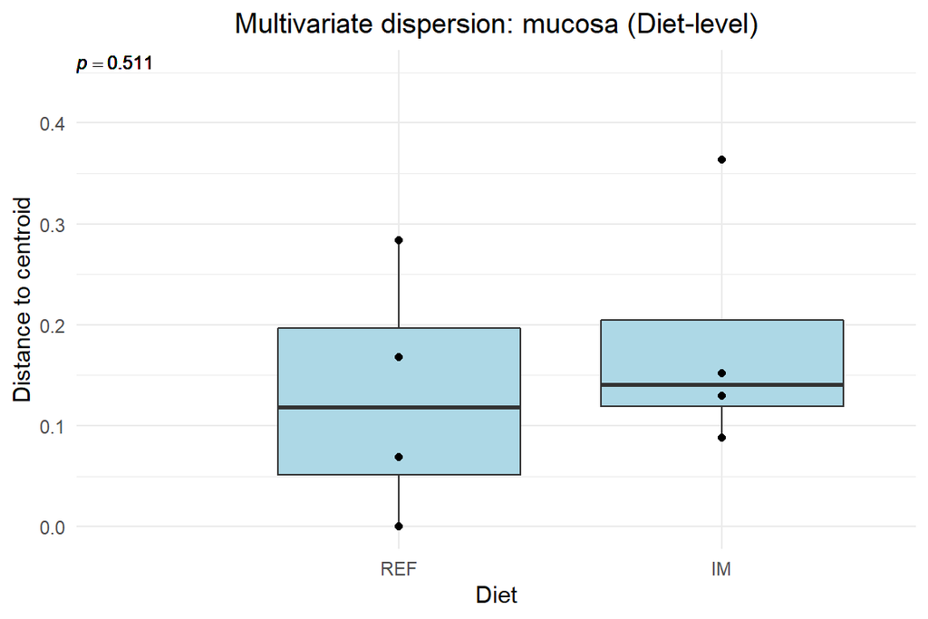

```r
dispVis_mcs_diet <- data.frame(
  dist = disp_mcs_diet$distances,
  group = disp_mcs_diet$group
  ) %>%
  ggplot(aes(x = group,y = dist)) +
    geom_boxplot(fill = "lightblue") +
    geom_point() +
    geom_text(
      aes(
        x = 0,
        y = 0.45,
        label = paste0("italic(p) == ", permdisp_mcs_diet$tab["Groups", "Pr(>F)"])
        ),
      size = 3,
      hjust = 0,
      vjust = 0,
      parse = TRUE
      ) +
    labs(
      x = "Diet", y = "Distance to centroid",
      title = "Multivariate dispersion: mucosa (Diet-level)"
      ) +
    theme_minimal() +
    theme(plot.title = element_text(hjust = 0.5))

dispVis_mcs_diet
```

## 4.3 Figure S3

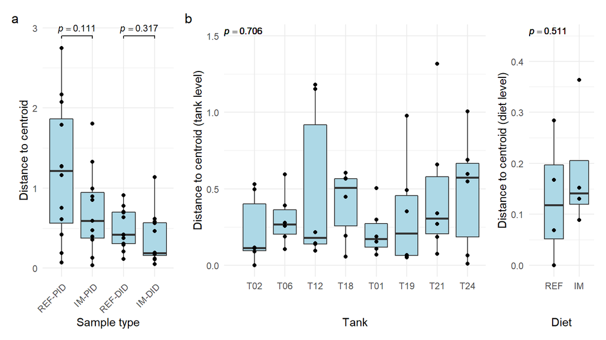

```r
dispVis_dgs + theme(axis.text.x = element_text(angle = 45, hjust = 1)) +
dispVis_mcs_tank + labs(y = "Distance to centroid (tank level)") +
dispVis_mcs_diet + labs(y = "Distance to centroid (diet level)") +
plot_layout(widths = c(2, 4, 1)) +
plot_annotation(tag_levels = list(c("a", "b", ""))) &
theme(plot.title = element_blank())
```

```r
# export plot
ggsave(here("result/figure/Figure S3.tiff"), width = 8, height = 4.5,
       units = "in", dpi = 300, compression = "lzw")
```